# Modelo lineal general

MSc. Darío Alvarado

[figure not shown]

Un **modelo lineal general** está basado en una **regresión lineal simple** o **múltiple** y sirve para determinar el efecto que tiene una variable predictora numérica sobre una variable respuesta numérica (Algo que no puede hacer un ANOVA), también sirve para evaluar si hay diferencias en una variable respuesta entre los niveles de una variable predictora categórica (similar al ANOVA).

#### Paquetes

```r
library(palmerpenguins)
library(tidyverse)
library(parameters)
library(performance)
library(AICcmodavg)
library(bbmle)
library(sjPlot)
library(estimatr)
library(modelbased)
library(emmeans)
library(ggeffects)
library(ggsignif)
```

### Contenido

#### Datos

```r
data("penguins")
head(penguins)
```

```
## # A tibble: 6 × 8
##   species island    bill_length_mm bill_depth_mm flipper_length_mm body_mass_g
##   <fct>   <fct>              <dbl>         <dbl>             <int>       <int>
## 1 Adelie  Torgersen           39.1          18.7               181        3750
## 2 Adelie  Torgersen           39.5          17.4               186        3800
## 3 Adelie  Torgersen           40.3          18                 195        3250
## 4 Adelie  Torgersen           NA            NA                  NA          NA
## 5 Adelie  Torgersen           36.7          19.3               193        3450
## 6 Adelie  Torgersen           39.3          20.6               190        3650
## # ℹ 2 more variables: sex <fct>, year <int>
```

Primero eliminamos los valores NA de nuestra base de datos con la función `drop_na()` del paquete `tidyr`, y para este ejercicio, por conveniencia pasaremos la masa corporal de gramos a kilogramos (para facilitar la interpretación).

```r
p <- penguins |>
  drop_na(body_mass_g) |>
  mutate(peso_kg = body_mass_g / 1000)

head(p)
```

```
## # A tibble: 6 × 9
##   species island    bill_length_mm bill_depth_mm flipper_length_mm body_mass_g
##   <fct>   <fct>              <dbl>         <dbl>             <int>       <int>
## 1 Adelie  Torgersen           39.1          18.7               181        3750
## 2 Adelie  Torgersen           39.5          17.4               186        3800
## 3 Adelie  Torgersen           40.3          18                 195        3250
## 4 Adelie  Torgersen           36.7          19.3               193        3450
## 5 Adelie  Torgersen           39.3          20.6               190        3650
## 6 Adelie  Torgersen           38.9          17.8               181        3625
## # ℹ 3 more variables: sex <fct>, year <int>, peso_kg <dbl>
```

Volver arriba

Inicio

#### Exploración de datos

Exploramos la relación existente entre nuestras variables de interés con un gráfico de dispersión (scatter plot).

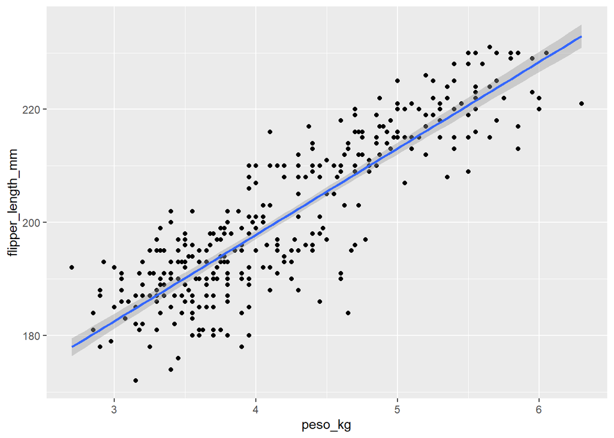

```r
ggplot(p, aes(peso_kg, flipper_length_mm)) +
  geom_point() +
  stat_smooth(method = lm) # con esto podemos ver si un modelo lineal (lm) se ajusta bien a nuestros datos
```

Volver arriba

Inicio

#### Modelo lineal general

La fórmula de un modelo lineal general es la siguiente:

- Regresión lineal simple

$$y_i = \beta_0 + \beta_1x_1 + \epsilon_i$$

- Regresión lineal múltiple

$$y_i = \beta_0 + \beta_1x_1 + \beta_2x_2 + ... \beta_nx_n + \epsilon_i$$

Donde:

- $y_i$ = variable respuesta (dependiente)
- $\beta_0$ = intercepto (ordenada al origen)
- $\beta_1$, $\beta_2$,…, $\beta_n$ = coeficiente de regresión de variables predictoras
- $x_1$, $x_2$,…, $x_n$ = variables predictoras (independientes)
- $\epsilon_i$ = error residual (variabilidad en la variable respuesta que no puede ser explicada con la relación lineal entre esta y la variable predictora)

Creamos nuestro modelo con la función `lm()` del paquete base de R, colocamos nuestra variable respuesta y después nuestra variable predictora separadas por una virgulilla (`~`).

```r
modelo1 <- lm(flipper_length_mm ~ peso_kg, data = p)
```

Volver arriba

Inicio

#### Resultado del modelo

Para ver el resultado de nuestro modelo hacemos un `summary()`:

```r
summary(modelo1)
```

```
##
## Call:
## lm(formula = flipper_length_mm ~ peso_kg, data = p)
##
## Residuals:
##      Min       1Q   Median       3Q      Max
## -23.7626  -4.9138   0.9891   5.1166  16.6392
##
## Coefficients:
##             Estimate Std. Error t value Pr(>|t|)
## (Intercept) 136.7296     1.9968   68.47   <2e-16 ***
## peso_kg      15.2759     0.4668   32.72   <2e-16 ***
## ---
## Signif. codes:  0 '***' 0.001 '**' 0.01 '*' 0.05 '.' 0.1 ' ' 1
##
## Residual standard error: 6.913 on 340 degrees of freedom
## Multiple R-squared:  0.759,  Adjusted R-squared:  0.7583
## F-statistic:  1071 on 1 and 340 DF,  p-value: < 2.2e-16
```

- Los residuales son la diferencia entre los valores predichos por el modelo y los valores observados (nuestros datos):

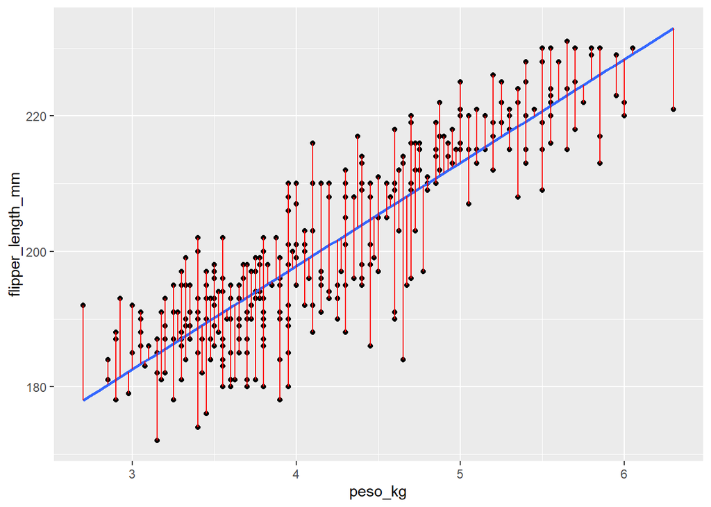

- El **intercepto** nos muestra el valor que tendría nuestra variable respuesta en el `eje y` cuando nuestra variable predictora es igual a `0` en el `eje x`:

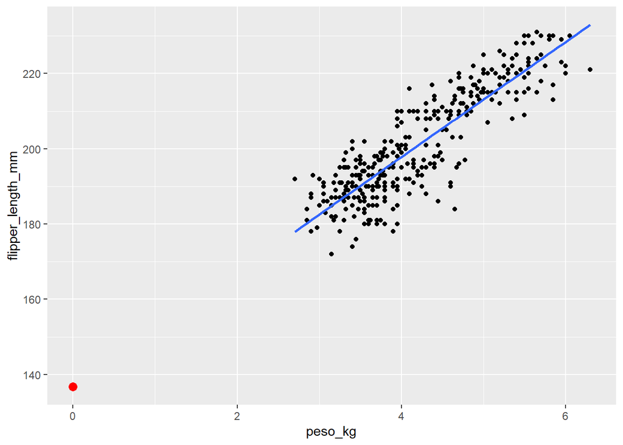

- El **estimado/coeficiente** bajo el intercepto muestra el efecto de nuestra variable predictora sobre la variable respuesta. Puede ser positivo o negativo.
- El **error estándar** es el error de la estimación de ese efecto.
- El **valor de p** indica si el efecto de la variable predictora sobre la variable respuesta es estadísticamente significativo.
  - Si **p < 0.05** = el efecto es estadísticamente significativo
  - Si **p ≥ 0.05** = el efecto no es estadísticamente significativo.
- El **error estándar residual** es el error del modelo y está en las unidades de la variable respuesta.
- El **R cuadrado múltiple** y el **R cuadrado ajustado** indican cuánto explica la variable predictora la varianza de la variable respuesta (El R cuadrado ajustado está corregido para el número de parámetros del modelo).

Volver arriba

Inicio